# Comparing Color Schemes: Color and Accessibility

Author

Affiliation

Yasmeen R’ghioui

George Washington University

Published

April 12, 2026

# 1) Overview

The dataset contains 100,000 student records spanning demographics like major, university tier, and region, alongside academic indicators such as GPA and prior internship experience. It tracks the full application funnel from submissions to first and second round interviews, all the way to offers received. For students who secured an offer, additional details like salary, company size, and role relevance are included.

## 2) Environment setup

```python
import pandas as pd
import numpy as np
import seaborn as sns
import matplotlib.pyplot as plt
import statsmodels.api as sm
from sklearn.datasets import load_iris
import matplotlib.colors as mcolors
import plotly.express as px
import altair as alt
data = pd.read_csv("job_data.csv")
```

## 3) GPA vs Offer Salary with Regression Line

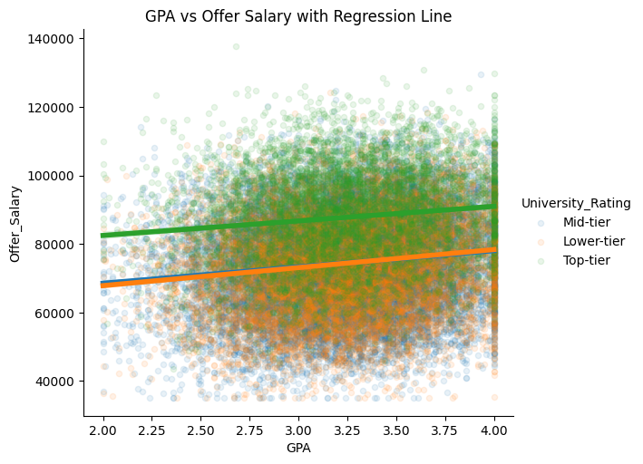

```python
data1 = data[["GPA", "Offer_Salary", "University_Rating"]].dropna()

sns.lmplot(
    data=data1,
    x="GPA",
    y="Offer_Salary",
    hue="University_Rating",
    height=5,
    aspect=1.2,
    ci=95,
    scatter_kws={"alpha": 0.1, "s": 20},
    line_kws={"linewidth": 4}
)

plt.title("GPA vs Offer Salary with Regression Line")
plt.show()
```

### 3a) GPA vs Offer Salary Random Sample

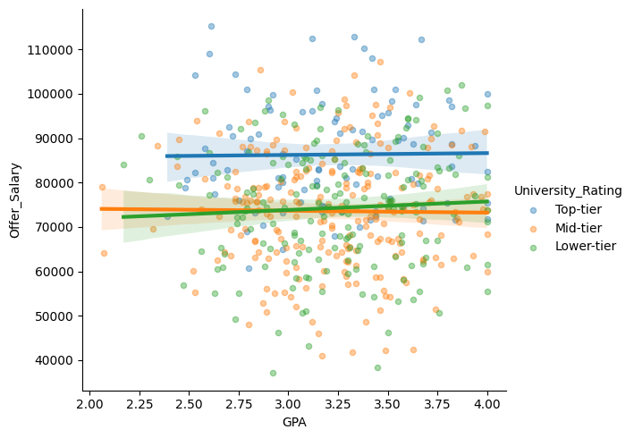

```python
data_sample = data1.sample(500, random_state=42)

sns.lmplot(
    data=data_sample,
    x="GPA",
    y="Offer_Salary",
    hue="University_Rating",
    ci=95,
    height=5,
    aspect=1.2,
    scatter_kws={"alpha": 0.4, "s": 20},
    line_kws={"linewidth": 3}
)
```